# Creating bivariate color palettes

Daniel Anderson

2019-08-30

# Bivariate palettes

Basically everything I came across when exploring how to create bivariate palettes were just a series of color codes. For example, in Timo’s example he uses the following code to create a bivariate color palette.

```r
library(tidyverse)
 bivariate_color_scale <- tibble(
  "3 - 3" = "#3F2949",
  "2 - 3" = "#435786",
  "1 - 3" = "#4885C1",
  "3 - 2" = "#77324C",
  "2 - 2" = "#806A8A",
  "1 - 2" = "#89A1C8",
  "3 - 1" = "#AE3A4E",
  "2 - 1" = "#BC7C8F",
  "1 - 1" = "#CABED0"
)
```

which then ends up looking like this

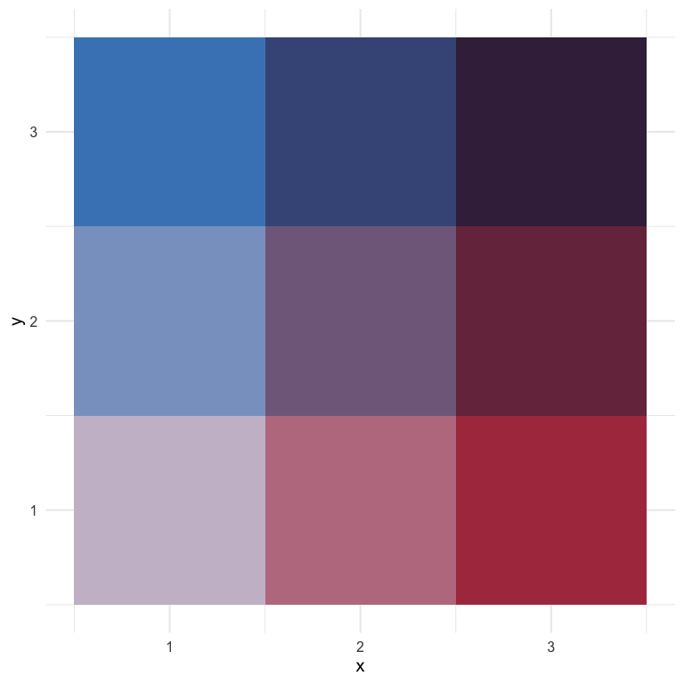

```r
bivariate_color_scale %>%
  gather("group", "fill") %>%
  separate(group, into = c("x", "y"), sep = " - ") %>%
  mutate(x = as.integer(x),
         y = as.integer(y)) %>%
ggplot(aes(x, y)) +
    geom_tile(aes(fill = fill)) +
    scale_fill_identity()
```

Joshua Stevens also provides similar 3 x 3 bivariate scales, and specifically cautions that it’s dangerous to go alone (exactly what I wanted to do!).

[interactive chart not shown]

But what if I wanted 4 or 5 categories? Or what if I even wanted to map continuous scales?

## Creating a custom palette

While looking around for different bivariate scales, I came across a [blog post by Len Kiefer](http://lenkiefer.com/2017/04/24/bivariate-map/) where he shows how to transform the viridis palette into a bivariate scale as follows (note: I’ve slightly modified his code to match my coding style)

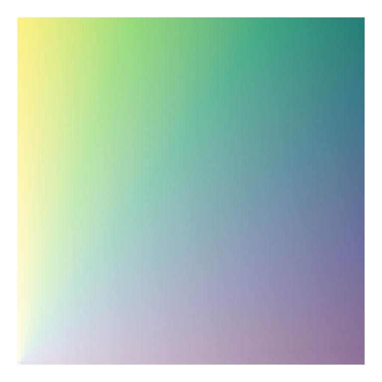

```r
d <- expand.grid(x = seq(0, 1, 0.01), y = seq(0, 1, 0.01)) %>%
  mutate(fill_val = atan(y/x),
         transparency = x + y)

ggplot(d, aes(x, y, fill = fill_val, alpha = transparency)) +
  geom_tile() +
  scale_fill_viridis_c() +
  theme_void() +
  theme(legend.position = "none")
```

Why do we divide `y` by `x` and take the arc tangent?… 🤷

I really have no idea, but it works! Part of what is interesting about this approach is that we change the *color* by (in part) changing the *transparency* of the fill. This is pretty clever, I think.

I also like this approach because it seems to work pretty well for just about any sequential palette. Here’s a few more examples

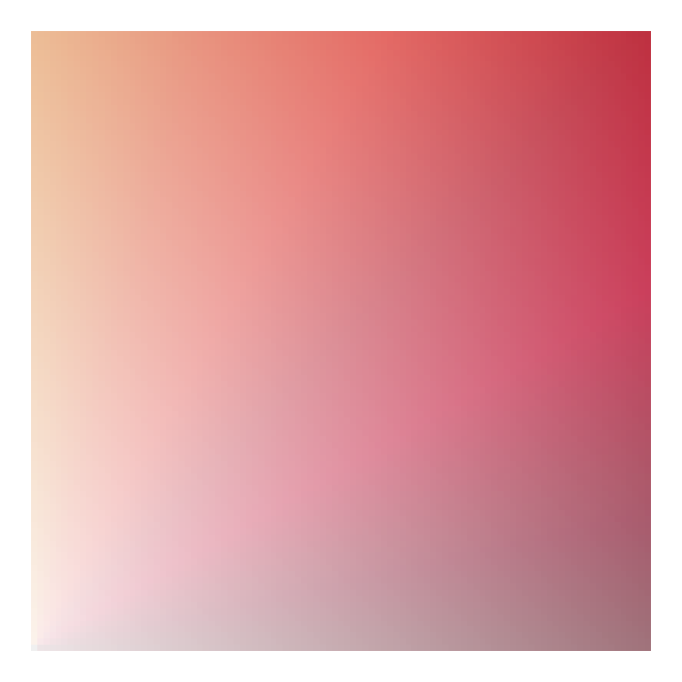

```r
# install.packages("paletteer")
library(paletteer)

ggplot(d, aes(x, y, fill = fill_val, alpha = transparency)) +
  geom_tile() +
  scale_fill_paletteer_c("harrypotter::hermionegranger") +
  theme_void() +
  theme(legend.position = "none")
```

And it even works fairly well for (some) diverging palettes.

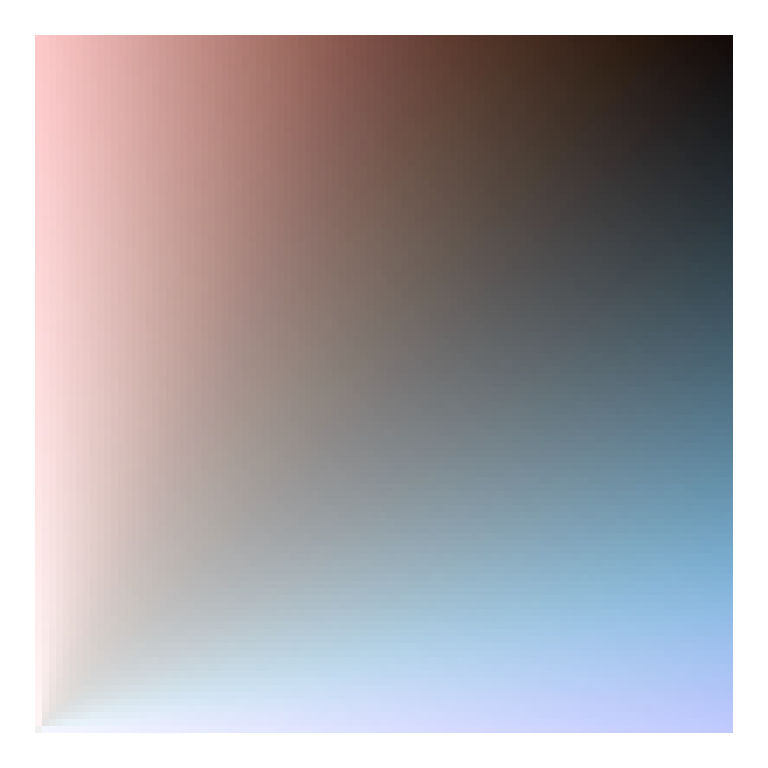

```r
ggplot(d, aes(x, y, fill = fill_val, alpha = transparency)) +
  geom_tile() +
  scale_fill_paletteer_c("scico::berlin") +
  theme_void() +
  theme(legend.position = "none")
```

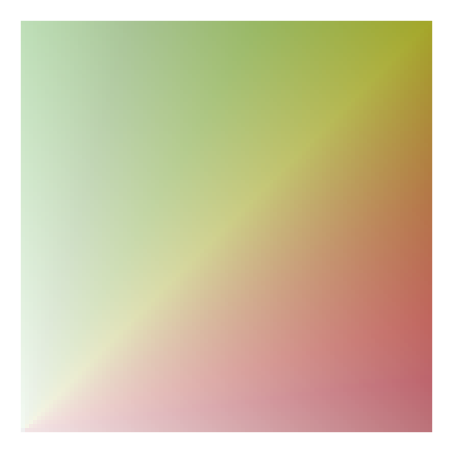

```r
ggplot(d, aes(x, y, fill = fill_val, alpha = transparency)) +
  geom_tile() +
  scale_fill_paletteer_c("harrypotter::harrypotter") +
  theme_void() +
  theme(legend.position = "none")
```

### Using rgb

Another alternative I came across from [this stackoverflow question/answer](https://stackoverflow.com/questions/11773295/how-can-one-mix-2-or-more-color-palettes-to-show-a-combined-color-value), is to just use the rgb values directly, varying one of the colors over many combinations of the other two. Here’s an example with (basically) the code from the accepted answer.

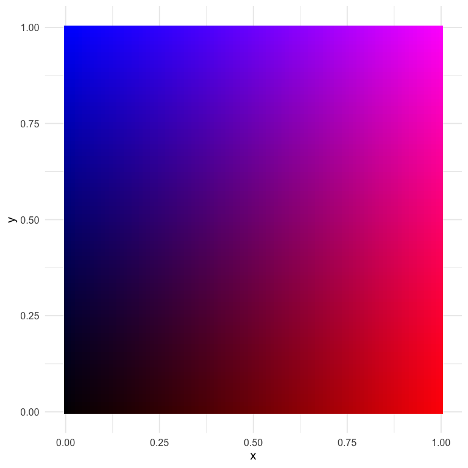

```r
d <- d %>%
  mutate(mix1 = rgb(red = x, green = 0, blue = y))

ggplot(d, aes(x, y)) +
  geom_tile(aes(fill = mix1)) +
  scale_fill_identity()
```

I think this one is actually quite nice, and it gives us almost infinite flexibility (which may not be a good thing). Let’s try again with slightly different values.

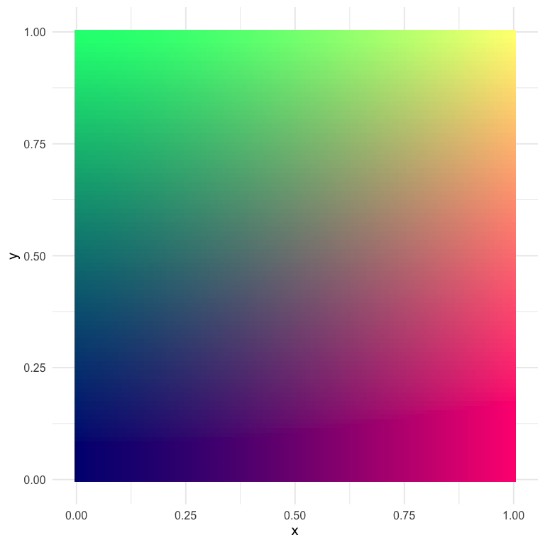

```r
d <- d %>%
  mutate(mix2 = rgb(red = x, green = y, blue = 0.5))

ggplot(d, aes(x, y)) +
  geom_tile(aes(fill = mix2)) +
  scale_fill_identity()
```

This one has some pretty distinct quadrants, which could be helpful if we’re thinking about having color represent two things.

# How do we actually use these scales?

So in the above, we’ve created and viewed a couple of different scales, but how do we go about using them with our data? There’s plenty of different ways, but I’m going to talk about the first way I thought of, which is a bit hacky but kind of neat.

## A ggplot hack

For this example, let’s play with the last palette we created. The data used to create any plot created from `ggplot2` can be returned using the `ggplot_build` function. Below, I first save the plot, then pull the data I want out using this function (and then limit the data to only the things I really want).

```r
p <- ggplot(d, aes(x, y)) +
  geom_tile(aes(fill = mix2)) +
  scale_fill_identity()

pal_d <- ggplot_build(p)$data[[1]] %>%
  select(x, y, fill) %>%
  mutate(x = as.character(x),
         y = as.character(y))
head(pal_d)
```

```
##      x y    fill
## 1    0 0 #000080
## 2 0.01 0 #030080
## 3 0.02 0 #050080
## 4 0.03 0 #080080
## 5 0.04 0 #0A0080
## 6 0.05 0 #0D0080
```

Now we have a palette that we can use by just rescaling our observed data to the $[0, 1]$ range! Notice also that I made the x and y values characters rather than doubles to help with the joining that will come (i.e., only two decimals of precision).

Let’s try with the `ggplot2::mpg` data set, coloring the points according to their values on each axis. We’ll show the correlation between engine displacement (`displ`) and highway miles per gallon (`hwy`).

```r
hwy_mpg <- mpg %>%
  mutate(x = as.character(round(scales::rescale(displ), 2)),
         y = as.character(round(scales::rescale(hwy), 2))) %>%
  left_join(pal_d)
hwy_mpg
```

```
## # A tibble: 234 x 14
##    manufacturer model displ  year   cyl trans drv     cty   hwy fl    class
##    <chr>        <chr> <dbl> <int> <int> <chr> <chr> <int> <int> <chr> <chr>
##  1 audi         a4      1.8  1999     4 auto… f        18    29 p     comp…
##  2 audi         a4      1.8  1999     4 manu… f        21    29 p     comp…
##  3 audi         a4      2    2008     4 manu… f        20    31 p     comp…
##  4 audi         a4      2    2008     4 auto… f        21    30 p     comp…
##  5 audi         a4      2.8  1999     6 auto… f        16    26 p     comp…
##  6 audi         a4      2.8  1999     6 manu… f        18    26 p     comp…
##  7 audi         a4      3.1  2008     6 auto… f        18    27 p     comp…
##  8 audi         a4 q…   1.8  1999     4 manu… 4        18    26 p     comp…
##  9 audi         a4 q…   1.8  1999     4 auto… 4        16    25 p     comp…
## 10 audi         a4 q…   2    2008     4 manu… 4        20    28 p     comp…
## # … with 224 more rows, and 3 more variables: x <chr>, y <chr>, fill <chr>
```

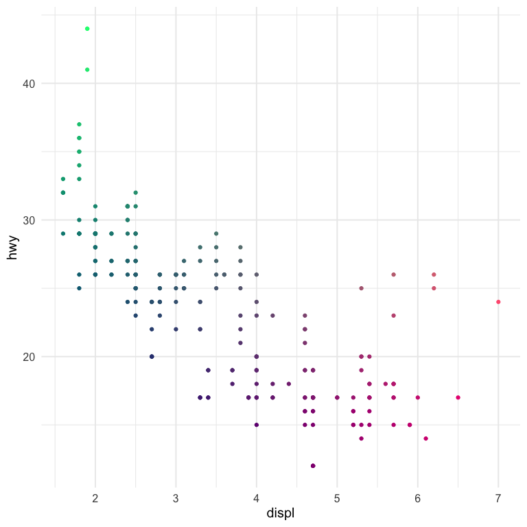

```r
ggplot(hwy_mpg, aes(displ, hwy)) +
  geom_point(aes(color = fill)) +
  scale_color_identity() +
  guides(color = "none")
```

And there we have it!

## A more realistic example

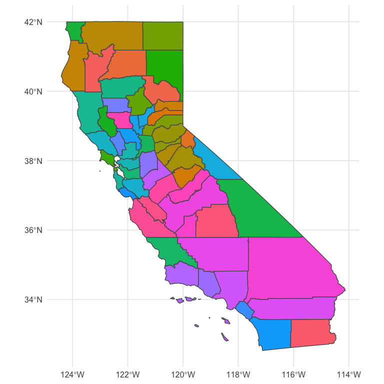

```r
library(tidycensus)
race_table <- get_acs(geography = "county",
                      geometry = TRUE,
                      output="wide",
                      table = "B03002",
                      state = "CA")

race_table <- race_table %>%
  select(county = NAME,
         hisp = B03002_012E,
         total = B03002_001E) %>%
  mutate(p_hisp = hisp/total)

earnings_table <- get_acs(geography = "county",
                          geometry = FALSE,
                          output="wide",
                          table = "B20018",
                          state = "CA") %>%
  select(county = NAME,
         earnings = B20018_001E)

geo <- left_join(race_table, earnings_table)
geo

geo <- geo %>%
  mutate(x = as.character(round(scales::rescale(p_hisp), 2)),
         y = as.character(round(scales::rescale(earnings), 2))) %>%
  left_join(pal_d)
geo

ggplot(geo) +
  geom_sf(aes(fill = fill)) +
  guides(fill = "none")
```

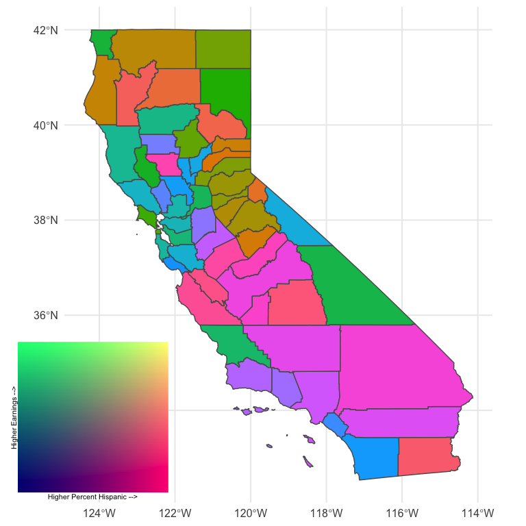

```r
library(cowplot)
map <- ggplot(geo) +
  geom_sf(aes(fill = fill)) +
  guides(fill = "none")

legend <- ggplot(pal_d, aes(x, y)) +
  geom_tile(aes(fill = fill)) +
  scale_fill_identity() +
  labs(x = "Higher Percent Hispanic -->",
       y = "Higher Earnings -->") +
  theme_void() +
  theme(axis.title = element_text(size = 8),
        axis.title.y = element_text(angle = 90)) +
  coord_fixed()

ggdraw() +
  draw_plot(map, 0, 0, 1, 1) +
  draw_plot(legend, 0.02, 0.05, 0.3, 0.3)
```

Importantly, I’m not sure this particular color scale is working as well as it could. In fact, I’m essentially positive we could get more interpretable results with another color scheme (perhaps a different one we used above). But it’s still sort of fun to play around with fully custom palettes. Finally, we might also benefit by collapsing the color scale into categories, as is more typical, because it would limit the number of colors and therefore limit the amount of information our brains are trying to process. Of course, that would also mean the colors would be slightly less representative of the actual bivariate value. Which *really* works best for lay or even moderately informed audiences is (at least for me) an open question.

# Wrapping up

That’s probably good for now. I know the actual producing of the choropleth was super fast, but I’ll try to follow up with a second blog post on tweaks there, and we’ll try different things like I mention above to try to make it better. But at least we’ve been able to go through the process and see a real-world example of where it may make sense to use a bivariate color scale.